# EDA

Dataset: UCI "Parking Birmingham" — car park occupancy readings collected across ~30 Birmingham lots, Oct–Dec 2016. 4 columns: `SystemCodeNumber` (lot ID), `Capacity`, `Occupancy`, `LastUpdated` (timestamp string).

```python
import pandas as pd

parking = pd.read_csv("C:\\Users\\aacha\\Downloads\\parking+birmingham\\dataset.csv")
```

```python
parking.info()
```

```
<class 'pandas.DataFrame'>
RangeIndex: 35717 entries, 0 to 35716
Data columns (total 4 columns):
 #   Column            Non-Null Count  Dtype
---  ------            --------------  -----
 0   SystemCodeNumber  35717 non-null  str
 1   Capacity          35717 non-null  int64
 2   Occupancy         35717 non-null  int64
 3   LastUpdated       35717 non-null  str
dtypes: int64(2), str(2)
memory usage: 1.1 MB
```

```python
parking.head()
```

|  | SystemCodeNumber | Capacity | Occupancy | LastUpdated |
| --- | --- | --- | --- | --- |
| 0 | BHMBCCMKT01 | 577 | 61 | 2016-10-04 07:59:42 |
| 1 | BHMBCCMKT01 | 577 | 64 | 2016-10-04 08:25:42 |
| 2 | BHMBCCMKT01 | 577 | 80 | 2016-10-04 08:59:42 |
| 3 | BHMBCCMKT01 | 577 | 107 | 2016-10-04 09:32:46 |
| 4 | BHMBCCMKT01 | 577 | 150 | 2016-10-04 09:59:48 |

```python
#Confirm no missing values
print(parking.isnull().sum())
```

```
SystemCodeNumber    0
Capacity            0
Occupancy           0
LastUpdated         0
dtype: int64
```

```python
#Numeric columns summary
parking.describe()
```

|  | Capacity | Occupancy |
| --- | --- | --- |
| count | 35717.000000 | 35717.000000 |
| mean | 1397.550130 | 642.228911 |
| std | 1179.326833 | 656.955535 |
| min | 220.000000 | -8.000000 |
| 25% | 500.000000 | 210.000000 |
| 50% | 849.000000 | 446.000000 |
| 75% | 2009.000000 | 798.000000 |
| max | 4675.000000 | 4327.000000 |

`Occupancy` has a negative minimum (-8), which is physically impossible — a data quality issue to revisit later. No missing values, so cleaning is limited to duplicates, timestamp parsing, and these invalid readings.

```python
for col in parking.select_dtypes(include='str').columns:
    print(col, '-> unique:', parking[col].nunique())
    print(parking[col].value_counts().head(10))
```

```
SystemCodeNumber -> unique: 30
SystemCodeNumber
BHMBCCMKT01         1312
BHMBCCTHL01         1312
BHMEURBRD01         1312
BHMMBMMBX01         1312
BHMNCPHST01         1312
BHMNCPNST01         1312
Broad Street        1312
Others-CCCPS105a    1312
Others-CCCPS119a    1312
Others-CCCPS135a    1312
Name: count, dtype: int64
LastUpdated -> unique: 1784
LastUpdated
2016-10-30 07:59:55    72
2016-10-28 08:16:41    56
2016-11-18 08:01:05    56
2016-11-25 08:00:57    54
2016-10-04 07:59:42    32
2016-10-18 08:01:23    31
2016-11-03 08:00:22    31
2016-12-06 07:56:10    31
2016-11-10 08:34:11    30
2016-10-16 09:01:15    29
Name: count, dtype: int64
```

# Data Cleaning

```python
print('Duplicate rows:', parking.duplicated().sum())
```

```
Duplicate rows: 216
```

```python
parking = parking.drop_duplicates()
```

216 exact full-row duplicates removed — same lot, same timestamp, same reading. Since every column matched, these are logging artifacts with no information value, safe to drop outright.

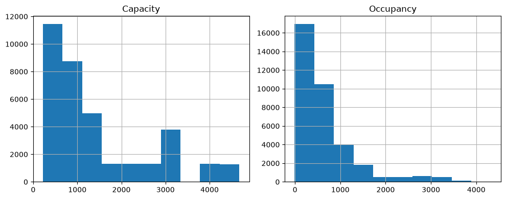

```python
import matplotlib.pyplot as plt

fig, axes = plt.subplots(1, 2, figsize=(10, 4))
parking.select_dtypes(include='number').hist(ax=axes)
plt.tight_layout()
plt.show()
```

```python
print(parking['SystemCodeNumber'].value_counts())
```

```
SystemCodeNumber
BHMBCCMKT01         1307
BHMBCCTHL01         1307
BHMMBMMBX01         1307
Others-CCCPS105a    1307
Others-CCCPS119a    1307
Others-CCCPS135a    1307
Others-CCCPS202     1307
Others-CCCPS8       1307
Others-CCCPS98      1307
Shopping            1307
BHMEURBRD01         1306
Broad Street        1306
BHMNCPHST01         1301
BHMNCPNST01         1299
BHMBCCSNH01         1289
Others-CCCPS133     1289
BHMNCPLDH01         1281
BHMBCCPST01         1271
BHMEURBRD02         1270
BHMNCPPLS01         1253
NIA Car Parks       1199
NIA South           1199
BHMBRCBRG02         1180
BHMBRCBRG03         1180
Bull Ring           1180
BHMBRCBRG01         1179
BHMNCPRAN01         1174
BHMNCPNHS01         1028
NIA North            159
BHMBRTARC01           88
Name: count, dtype: int64
```

## Timestamp Parsing & Gap Analysis

Convert `LastUpdated` to a real datetime, sort chronologically per lot, and confirm `Capacity` is constant per lot (required for later resampling).

```python
parking['LastUpdated'] = pd.to_datetime(parking['LastUpdated'])
parking = parking.sort_values(['SystemCodeNumber', 'LastUpdated'])
```

```python
print(parking['LastUpdated'].dtype)   # should say datetime64[ns]
parking['LastUpdated'].head()
```

```
datetime64[us]
```

```
0   2016-10-04 07:59:42
1   2016-10-04 08:25:42
2   2016-10-04 08:59:42
3   2016-10-04 09:32:46
4   2016-10-04 09:59:48
Name: LastUpdated, dtype: datetime64[us]
```

```python
parking = parking.sort_values(['SystemCodeNumber', 'LastUpdated']).reset_index(drop=True)
```

```python
capacity_check = parking.groupby('SystemCodeNumber')['Capacity'].nunique()
print(capacity_check[capacity_check > 1])
```

```
Series([], Name: Capacity, dtype: int64)
```

Confirmed: every lot has exactly one `Capacity` value. No conflicting readings to resolve.

```python
parking.head()
```

|  | SystemCodeNumber | Capacity | Occupancy | LastUpdated |
| --- | --- | --- | --- | --- |
| 0 | BHMBCCMKT01 | 577 | 61 | 2016-10-04 07:59:42 |
| 1 | BHMBCCMKT01 | 577 | 64 | 2016-10-04 08:25:42 |
| 2 | BHMBCCMKT01 | 577 | 80 | 2016-10-04 08:59:42 |
| 3 | BHMBCCMKT01 | 577 | 107 | 2016-10-04 09:32:46 |
| 4 | BHMBCCMKT01 | 577 | 150 | 2016-10-04 09:59:48 |

Measure the time between consecutive readings per lot to determine the dataset's natural sampling rate — this will drive the resample frequency choice below.

```python
parking['gap'] = parking.groupby('SystemCodeNumber')['LastUpdated'].diff()

print(parking['gap'].value_counts().head(20))
```

```
gap
0 days 00:33:00    2116
0 days 00:27:00    1793
0 days 00:27:01    1727
0 days 00:33:01    1540
0 days 00:32:59    1276
0 days 00:27:02    1257
0 days 00:26:58    1253
0 days 00:33:02    1150
0 days 00:26:00    1097
0 days 00:34:01    1074
0 days 00:26:59    1036
0 days 00:32:58     827
0 days 00:34:00     810
0 days 00:33:59     803
0 days 00:26:02     732
0 days 00:33:03     714
0 days 00:26:01     710
0 days 00:26:56     644
0 days 00:27:04     636
0 days 00:26:57     617
Name: count, dtype: int64
```

```python
print(parking['gap'].describe())
print(parking['gap'].max())
```

```
count                     35471
mean     0 days 01:28:36.476360
std      0 days 05:22:14.516775
min             0 days 00:05:58
25%             0 days 00:26:59
50%             0 days 00:32:56
75%             0 days 00:33:04
max             9 days 15:48:47
Name: gap, dtype: object
9 days 15:48:47
```

```python
per_lot_median = parking.groupby('SystemCodeNumber')['LastUpdated'].diff().dt.total_seconds().div(60).groupby(parking['SystemCodeNumber']).median()
print(per_lot_median.describe())
print(per_lot_median.sort_values())
```

```
count    30.000000
mean     32.923889
std       0.012898
min      32.916667
25%      32.916667
50%      32.916667
75%      32.933333
max      32.966667
Name: LastUpdated, dtype: float64
SystemCodeNumber
BHMBCCMKT01         32.916667
BHMBCCPST01         32.916667
BHMBCCSNH01         32.916667
BHMBCCTHL01         32.916667
BHMBRCBRG02         32.916667
BHMBRTARC01         32.916667
BHMMBMMBX01         32.916667
BHMEURBRD01         32.916667
Others-CCCPS133     32.916667
Others-CCCPS119a    32.916667
NIA South           32.916667
Others-CCCPS105a    32.916667
NIA North           32.916667
NIA Car Parks       32.916667
Bull Ring           32.916667
Broad Street        32.916667
Others-CCCPS98      32.916667
Others-CCCPS135a    32.916667
Others-CCCPS202     32.916667
Others-CCCPS8       32.916667
Shopping            32.916667
BHMEURBRD02         32.933333
BHMBRCBRG01         32.933333
BHMBRCBRG03         32.933333
BHMNCPHST01         32.933333
BHMNCPRAN01         32.933333
BHMNCPLDH01         32.933333
BHMNCPNHS01         32.950000
BHMNCPNST01         32.950000
BHMNCPPLS01         32.966667
Name: LastUpdated, dtype: float64
```

Every lot's median gap clusters tightly around **~33 minutes**, with almost no spread across lots. This consistency points to a shared polling schedule rather than independent per-lot sensor behavior.

```python
parking.groupby('SystemCodeNumber')['LastUpdated'].apply(lambda x: x.dt.second.mode())
```

```
SystemCodeNumber
BHMBCCMKT01       0     3
BHMBCCPST01       0     3
BHMBCCSNH01       0     3
BHMBCCTHL01       0     3
BHMBRCBRG01       0     3
BHMBRCBRG02       0     3
BHMBRCBRG03       0     3
BHMBRTARC01       0    17
BHMEURBRD01       0     3
BHMEURBRD02       0     3
BHMMBMMBX01       0     3
BHMNCPHST01       0     3
BHMNCPLDH01       0    22
BHMNCPNHS01       0     3
BHMNCPNST01       0     3
BHMNCPPLS01       0     3
BHMNCPRAN01       0     3
Broad Street      0     3
Bull Ring         0     3
NIA Car Parks     0     3
NIA North         0    51
NIA South         0     3
Others-CCCPS105a  0     3
Others-CCCPS119a  0     3
Others-CCCPS133   0     3
Others-CCCPS135a  0     3
Others-CCCPS202   0     3
Others-CCCPS8     0     3
Others-CCCPS98    0     3
Shopping          0     3
Name: LastUpdated, dtype: int32
```

**Conclusion on resample frequency:** the true intended polling interval is almost certainly a round **30 minutes** — the observed 33min median is 30min plus a small systematic delay from the collection process (confirmed by the consistent `:03`-second offset). Resampling at 33min would bake this measurement artifact into the pipeline; resampling at 30min corrects for it and keeps a clean, round grid for downstream feature engineering.

## Resampling to a Fixed 30-Minute Grid

Resample each lot independently onto a regular 30-min grid. This creates explicit `NaN` rows wherever no reading existed in a given window — intentional, so gaps are visible and handled deliberately rather than silently smoothed over.

```python
# Make sure LastUpdated is the index (required for resample)
parking = parking.set_index('LastUpdated')

# Resample per lot onto a fixed 30-min grid
resampled = (
    parking.groupby('SystemCodeNumber')
      .resample('30min')
      .agg({'Occupancy': 'mean', 'Capacity': 'first'})
)

# Flatten the MultiIndex (SystemCodeNumber, LastUpdated) back into columns
resampled = resampled.reset_index()

resampled.head()
```

|  | SystemCodeNumber | LastUpdated | Occupancy | Capacity |
| --- | --- | --- | --- | --- |
| 0 | BHMBCCMKT01 | 2016-10-04 07:30:00 | 61.0 | 577.0 |
| 1 | BHMBCCMKT01 | 2016-10-04 08:00:00 | 64.0 | 577.0 |
| 2 | BHMBCCMKT01 | 2016-10-04 08:30:00 | 80.0 | 577.0 |
| 3 | BHMBCCMKT01 | 2016-10-04 09:00:00 | NaN | NaN |
| 4 | BHMBCCMKT01 | 2016-10-04 09:30:00 | 128.5 | 577.0 |

```python
missing = resampled['Occupancy'].isna().sum()
total = len(resampled)
print(f"Missing: {missing} / {total} ({missing/total:.1%})")
```

```
Missing: 78125 / 104823 (74.5%)
```

74.5% missing is far higher than the ~33min cadence would predict at 30min resolution. Investigate whether this is a genuine data reliability issue or an artifact of resampling across hours/days the lots were never actually operating.

```python
hour_counts = parking.index.hour.value_counts().sort_index()
print(hour_counts)
```

```
LastUpdated
7      741
8     3900
9     4032
10    3829
11    3981
12    3855
13    4139
14    3945
15    3942
16    3137
Name: count, dtype: int64
```

Readings are concentrated in hours 7–16 (business hours), with hour 7 dramatically underrepresented — likely the ragged edge where the polling system was still starting up for the day. Restrict the operating window and re-check missingness.

```python
resampled_filtered = resampled[
    (resampled['LastUpdated'].dt.hour >= 7) &
    (resampled['LastUpdated'].dt.hour <= 16)   # adjust based on what hour_counts shows
]

missing = resampled_filtered['Occupancy'].isna().sum()
total = len(resampled_filtered)
print(f"Missing: {missing} / {total} ({missing/total:.1%})")
```

```
Missing: 17309 / 44007 (39.3%)
```

```python
resampled_filtered['dow'] = resampled_filtered['LastUpdated'].dt.day_name()
resampled_filtered.groupby('dow')['Occupancy'].apply(lambda x: x.isna().mean())
```

```
dow
Friday       0.457619
Monday       0.369808
Saturday     0.434505
Sunday       0.402039
Thursday     0.397302
Tuesday      0.370588
Wednesday    0.321728
Name: Occupancy, dtype: float64
```

```python
resampled_filtered.groupby(resampled_filtered['LastUpdated'].dt.hour)['Occupancy'].apply(lambda x: x.isna().mean())
```

```
LastUpdated
7     0.830512
8     0.349909
9     0.336285
10    0.334469
11    0.340599
12    0.353769
13    0.304496
14    0.329019
15    0.353315
16    0.404043
Name: Occupancy, dtype: float64
```

```python
per_lot_missing = resampled_filtered.groupby('SystemCodeNumber')['Occupancy'].apply(lambda x: x.isna().mean())
print(per_lot_missing.sort_values(ascending=False).head(10))
print(per_lot_missing.describe())
```

```
SystemCodeNumber
NIA North        0.875682
BHMNCPNHS01      0.491228
BHMBRTARC01      0.440678
BHMNCPRAN01      0.430149
BHMBRCBRG03      0.428850
BHMBRCBRG01      0.427550
BHMBRCBRG02      0.427550
Bull Ring        0.427550
NIA Car Parks    0.393509
NIA South        0.393509
Name: Occupancy, dtype: float64
count    30.000000
mean      0.401280
std       0.095718
min       0.360624
25%       0.360624
50%       0.369396
75%       0.419040
max       0.875682
Name: Occupancy, dtype: float64
```

```python
date_range = parking.groupby('SystemCodeNumber').apply(lambda g: (g.index.min(), g.index.max(), (g.index.max() - g.index.min()).days))
print(date_range)
```

```
SystemCodeNumber
BHMBCCMKT01         (2016-10-04 07:59:42, 2016-12-19 16:30:35, 76)
BHMBCCPST01         (2016-10-04 07:59:42, 2016-12-19 16:30:35, 76)
BHMBCCSNH01         (2016-10-04 07:59:42, 2016-12-19 16:30:35, 76)
BHMBCCTHL01         (2016-10-04 07:59:42, 2016-12-19 16:30:35, 76)
BHMBRCBRG01         (2016-10-04 07:59:42, 2016-12-19 16:30:35, 76)
BHMBRCBRG02         (2016-10-04 07:59:42, 2016-12-19 16:30:35, 76)
BHMBRCBRG03         (2016-10-04 07:59:42, 2016-12-19 16:30:35, 76)
BHMBRTARC01          (2016-12-13 08:02:51, 2016-12-18 16:30:25, 5)
BHMEURBRD01         (2016-10-04 07:59:42, 2016-12-19 16:30:35, 76)
BHMEURBRD02         (2016-10-04 07:59:42, 2016-12-19 16:30:35, 76)
BHMMBMMBX01         (2016-10-04 07:59:42, 2016-12-19 16:30:35, 76)
BHMNCPHST01         (2016-10-04 07:59:42, 2016-12-19 16:30:35, 76)
BHMNCPLDH01         (2016-10-04 07:59:42, 2016-12-19 16:30:35, 76)
BHMNCPNHS01         (2016-10-04 07:59:42, 2016-12-19 16:30:35, 76)
BHMNCPNST01         (2016-10-04 07:59:42, 2016-12-19 16:30:35, 76)
BHMNCPPLS01         (2016-10-04 07:46:28, 2016-12-19 16:30:35, 76)
BHMNCPRAN01         (2016-10-04 07:59:42, 2016-12-19 16:30:35, 76)
Broad Street        (2016-10-04 07:59:42, 2016-12-19 16:30:35, 76)
Bull Ring           (2016-10-04 07:59:42, 2016-12-19 16:30:35, 76)
NIA Car Parks       (2016-10-04 07:59:42, 2016-12-16 16:30:12, 73)
NIA North           (2016-10-16 08:01:13, 2016-11-30 16:28:40, 45)
NIA South           (2016-10-04 07:59:42, 2016-12-16 16:30:12, 73)
Others-CCCPS105a    (2016-10-04 07:59:42, 2016-12-19 16:30:35, 76)
Others-CCCPS119a    (2016-10-04 07:59:42, 2016-12-19 16:30:35, 76)
Others-CCCPS133     (2016-10-04 07:59:42, 2016-12-19 16:30:35, 76)
Others-CCCPS135a    (2016-10-04 07:59:42, 2016-12-19 16:30:35, 76)
Others-CCCPS202     (2016-10-04 07:59:42, 2016-12-19 16:30:35, 76)
Others-CCCPS8       (2016-10-04 07:59:42, 2016-12-19 16:30:35, 76)
Others-CCCPS98      (2016-10-04 07:59:42, 2016-12-19 16:30:35, 76)
Shopping            (2016-10-04 07:59:42, 2016-12-19 16:30:35, 76)
dtype: object
```

```python
resampled_filtered = resampled[
    (resampled['LastUpdated'].dt.hour >= 8) &
    (resampled['LastUpdated'].dt.hour <= 16)
].copy()

# confirm the fix
missing = resampled_filtered['Occupancy'].isna().sum()
total = len(resampled_filtered)
print(f"Missing after dropping hour 7: {missing} / {total} ({missing/total:.1%})")
```

```
Missing after dropping hour 7: 13678 / 39635 (34.5%)
```

Dropping hour 7 brings missingness down from 39.3% to 34.5%, but a meaningful baseline remains even within core operating hours. Break this down by lot and day-of-week to find the remaining drivers.

```python
# Find the raw rows with negative occupancy
neg_raw = parking[parking['Occupancy'] < 0]
print(neg_raw[['SystemCodeNumber', 'Occupancy']])
print(f"\nTotal negative raw rows: {len(neg_raw)}")
```

```
                    SystemCodeNumber  Occupancy
LastUpdated
2016-10-16 15:57:16        NIA North         -3
2016-10-16 16:31:17        NIA North         -3
2016-10-18 15:27:59        NIA North         -1
2016-10-28 13:02:43        NIA North         -8
2016-10-28 15:29:41        NIA North         -1
2016-10-28 16:02:40        NIA North         -4
2016-10-28 16:29:42        NIA North         -1
2016-10-29 12:59:51        NIA North         -2
2016-10-29 16:26:53        NIA North         -1
2016-11-10 16:00:15        NIA North         -3
2016-11-30 15:28:40        NIA North         -1
2016-11-30 16:01:39        NIA North         -2

Total negative raw rows: 12
```

```python
check_lots = ['NIA Car Parks', 'NIA South']
per_lot = resampled_filtered.groupby('SystemCodeNumber')['Occupancy'].apply(lambda x: x.isna().mean())
print(per_lot.loc[check_lots])
```

```
SystemCodeNumber
NIA Car Parks    0.344595
NIA South        0.344595
Name: Occupancy, dtype: float64
```

Two clear patterns:

Two other lots (`NIA Car Parks`, `NIA South`) also appeared near the top of the missingness list but have a full date range (~73 days, unlike the two above) — these are rechecked separately after dropping hour 7 to see whether their elevated missingness was a genuine issue or just an hour-7 artifact.

Decision: drop hour 7, then drop the two clearly unreliable lots (`NIA North`, `BHMBRTARC01`), and re-evaluate the rest.

```python
lots_to_drop = ['NIA North', 'BHMBRTARC01']

resampled_clean = resampled_filtered[
    ~resampled_filtered['SystemCodeNumber'].isin(lots_to_drop)
].copy()

print(f"Lots remaining: {resampled_clean['SystemCodeNumber'].nunique()}")
print(f"Rows before: {len(resampled_filtered)}, after: {len(resampled_clean)}")
```

```
Lots remaining: 28
Rows before: 39635, after: 38700
```

```python
missing = resampled_clean['Occupancy'].isna().sum()
total = len(resampled_clean)
print(f"Missing after both fixes: {missing} / {total} ({missing/total:.1%})")
```

```
Missing after both fixes: 12919 / 38700 (33.4%)
```

```python
# and confirm no single lot is still a huge outlier
per_lot_final = resampled_clean.groupby('SystemCodeNumber')['Occupancy'].apply(lambda x: x.isna().mean())
print(per_lot_final.sort_values(ascending=False).head(28))
```

```
SystemCodeNumber
BHMNCPNHS01         0.450938
BHMNCPRAN01         0.386724
BHMBRCBRG03         0.383117
BHMBRCBRG01         0.383117
BHMBRCBRG02         0.381674
Bull Ring           0.381674
NIA Car Parks       0.344595
NIA South           0.344595
BHMEURBRD02         0.333333
BHMNCPPLS01         0.330447
BHMBCCPST01         0.329726
BHMNCPLDH01         0.326118
Others-CCCPS133     0.320346
BHMBCCSNH01         0.316739
BHMNCPNST01         0.314574
BHMNCPHST01         0.313853
BHMBCCMKT01         0.309524
BHMMBMMBX01         0.308802
BHMBCCTHL01         0.308802
BHMEURBRD01         0.308802
Broad Street        0.308802
Others-CCCPS105a    0.308802
Others-CCCPS119a    0.308802
Others-CCCPS135a    0.308802
Others-CCCPS202     0.308802
Others-CCCPS8       0.308802
Others-CCCPS98      0.308802
Shopping            0.308802
Name: Occupancy, dtype: float64
```

33.4% overall, with `BHMNCPNHS01` still elevated (45%) but not extreme like the dropped lots — keeping it and handling its gaps via the interpolation strategy below rather than dropping it outright.

```python
lot_data = resampled_clean[resampled_clean['SystemCodeNumber'] == 'BHMNCPNHS01'].sort_values('LastUpdated')
lot_data['is_missing'] = lot_data['Occupancy'].isna()

# missingness by month, to spot a specific bad stretch vs. spread-out gaps
lot_data.groupby(lot_data['LastUpdated'].dt.to_period('M'))['is_missing'].mean()
```

```
LastUpdated
2016-10    0.523810
2016-11    0.405556
2016-12    0.415205
Freq: M, Name: is_missing, dtype: float64
```

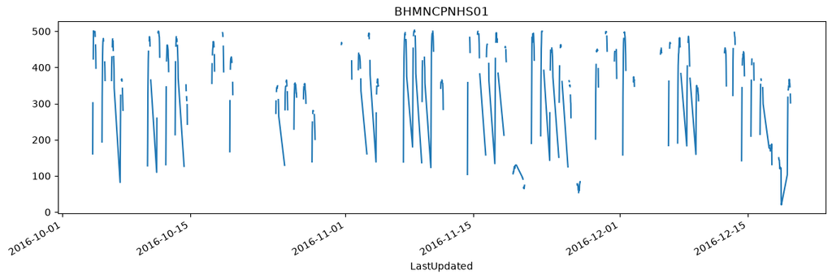

```python
lot_data.set_index('LastUpdated')['Occupancy'].plot(figsize=(14,4), title='BHMNCPNHS01')
```

## Gap-Length Analysis & Interpolation

Before filling any missing values, measure how long individual gaps (consecutive missing streaks) actually are. Short gaps are safe to interpolate; long gaps should be left as genuine missing data rather than fabricated.

```python
# work per lot, since gaps are lot-specific
resampled_clean = resampled_clean.sort_values(['SystemCodeNumber', 'LastUpdated'])

resampled_clean['is_missing'] = resampled_clean['Occupancy'].isna()

# identify consecutive missing streaks per lot
resampled_clean['gap_group'] = (
    resampled_clean.groupby('SystemCodeNumber')['is_missing']
    .apply(lambda x: (x != x.shift()).cumsum())
    .reset_index(drop=True)
)

gap_lengths = (
    resampled_clean[resampled_clean['is_missing']]
    .groupby(['SystemCodeNumber', 'gap_group'])
    .size()
)

print(gap_lengths.describe())
```

```
count    2765.000000
mean        1.759132
std         1.676601
min         1.000000
25%         1.000000
50%         1.000000
75%         2.000000
max        27.000000
dtype: float64
```

```python
print(gap_lengths.value_counts().sort_index().head(15))
```

```
1     1806
2      533
3      185
4      104
5       48
6       24
7       18
8       10
9       11
10       6
11       7
12       4
13       2
14       3
16       1
Name: count, dtype: int64
```

Heavily right-skewed: ~95% of gap *events* are 4 steps (2 hours) or shorter, and gaps of length 1–2 alone account for ~59% of all missing rows. This supports capping interpolation at 4 steps — short gaps get a defensible linear fill, while the long tail (2.5+ hours) is left as real missing data rather than guessed at.

```python
total_missing_rows = gap_lengths.sum()
print(f"Total missing rows: {total_missing_rows}")
print(f"Gaps of length 1-2 account for: {(1806*1 + 533*2) / total_missing_rows:.1%} of missing rows")
```

```
Total missing rows: 4864
Gaps of length 1-2 account for: 59.0% of missing rows
```

```python
MAX_FILL_STEPS = 4

resampled_clean['Occupancy_filled'] = (
    resampled_clean.groupby('SystemCodeNumber')['Occupancy']
    .transform(lambda x: x.interpolate(method='linear', limit=MAX_FILL_STEPS, limit_area='inside'))
)

resampled_clean['was_imputed'] = (
    resampled_clean['Occupancy'].isna() & resampled_clean['Occupancy_filled'].notna()
)

still_missing = resampled_clean['Occupancy_filled'].isna().sum()
total = len(resampled_clean)
print(f"Still missing after fill: {still_missing} / {total} ({still_missing/total:.1%})")
print(f"Rows imputed: {resampled_clean['was_imputed'].sum()}")
```

```
Still missing after fill: 2885 / 38700 (7.5%)
Rows imputed: 10034
```

Missingness reduced from 33.4% to 7.5% via capped linear interpolation (≤4 steps / 2 hours), with 10,034 rows filled and flagged via `was_imputed`. The remaining 7.5% (long gaps of 2.5+ hours) are dropped — filling them would fabricate multi-hour trends the data doesn't actually support.

Resampling created empty rows for every missing time slot, which also nulled out `Capacity` (a static per-lot value) in those rows. Forward/backward-fill it — safe since it's a known constant, not something being estimated.

```python
resampled_clean['Capacity'] = (
    resampled_clean.groupby('SystemCodeNumber')['Capacity']
    .transform(lambda x: x.ffill().bfill())
)

print(resampled_clean['Capacity'].isna().sum())  # should be 0
```

```
0
```

```python
final_df = resampled_clean.dropna(subset=['Occupancy_filled']).copy()
final_df = final_df.drop(columns=['gap_group', 'is_missing', 'Occupancy'])
final_df = final_df.rename(columns={'Occupancy_filled': 'Occupancy'})
```

```python
final_df.info()
```

```
<class 'pandas.DataFrame'>
Index: 35815 entries, 1 to 104822
Data columns (total 5 columns):
 #   Column            Non-Null Count  Dtype
---  ------            --------------  -----
 0   SystemCodeNumber  35815 non-null  str
 1   LastUpdated       35815 non-null  datetime64[us]
 2   Capacity          35815 non-null  float64
 3   Occupancy         35815 non-null  float64
 4   was_imputed       35815 non-null  bool
dtypes: bool(1), datetime64[us](1), float64(2), str(1)
memory usage: 1.4 MB
```

Base table finalized: `SystemCodeNumber`, `LastUpdated`, `Capacity`, `Occupancy` (post-fill), `was_imputed`. No remaining NaNs. This is the clean starting point for feature engineering — the raw `Occupancy` (pre-fill) is discarded since `was_imputed` already preserves which rows were touched.

## Feature Engineering

Build the target variable and predictive features. First: normalize occupancy into a rate (0–1) so lots of different sizes are directly comparable — important since lots will later be pooled into a single model.

```python
final_df['OccupancyRate'] = final_df['Occupancy'] / final_df['Capacity']
```

```python
final_df['hour'] = final_df['LastUpdated'].dt.hour
final_df['dayofweek'] = final_df['LastUpdated'].dt.dayofweek      # 0=Monday
final_df['is_weekend'] = final_df['dayofweek'].isin([5, 6]).astype(int)
final_df['date'] = final_df['LastUpdated'].dt.date
```

```python
print(final_df['OccupancyRate'].describe())
```

```
count    35815.000000
mean         0.500859
std          0.264707
min          0.000000
25%          0.270305
50%          0.483250
75%          0.715779
max          1.041344
Name: OccupancyRate, dtype: float64
```

```python
print((final_df['OccupancyRate'] > 1).sum())  # flag any lot where occupancy exceeded capacity
```

```
357
```

```python
over_cap = final_df[final_df['OccupancyRate'] > 1]

# is it concentrated in specific lots?
print(over_cap['SystemCodeNumber'].value_counts())
```

```
SystemCodeNumber
BHMBCCTHL01    235
BHMBRCBRG01     84
BHMBRCBRG02     24
BHMBCCSNH01      9
BHMNCPNHS01      3
BHMBCCPST01      1
BHMMBMMBX01      1
Name: count, dtype: int64
```

```python
# is it concentrated in specific dates/times?
print(over_cap['hour'].value_counts())
```

```
hour
13    97
12    81
14    75
11    41
15    37
16    16
10     7
9      2
8      1
Name: count, dtype: int64
```

357 rows exceed a rate of 1.0, heavily concentrated in `BHMBCCTHL01` (66% of cases) and clustered around midday peak hours (11am–3pm) — consistent with these lots' stated `Capacity` being set too low relative to their true physical maximum, rather than random sensor noise.

```python
print(over_cap['LastUpdated'].dt.date.value_counts())
```

```
LastUpdated
2016-12-11    20
2016-11-19    17
2016-11-26    17
2016-11-27    17
2016-12-10    16
2016-12-17    16
2016-11-25    14
2016-12-19    14
2016-12-06    11
2016-11-20    11
2016-12-14    11
2016-12-18    11
2016-11-23    10
2016-12-01    10
2016-12-07    10
2016-12-08    10
2016-12-12    10
2016-11-28     9
2016-12-02     9
2016-11-29     8
2016-11-30     8
2016-12-09     8
2016-12-16     8
2016-12-15     7
2016-11-17     6
2016-12-13     6
2016-11-22     5
2016-11-24     5
2016-12-05     5
2016-10-22     5
2016-11-12     5
2016-10-23     4
2016-10-29     4
2016-10-30     4
2016-11-06     4
2016-10-15     3
2016-10-26     3
2016-11-05     3
2016-10-16     2
2016-10-27     2
2016-11-08     2
2016-10-08     1
2016-11-18     1
2016-10-24     1
2016-10-25     1
2016-10-28     1
2016-11-13     1
2016-10-04     1
Name: count, dtype: int64
```

```python
# check how much each affected lot actually peaks at
affected_lots = ['BHMBCCTHL01', 'BHMBRCBRG01', 'BHMBRCBRG02']

for lot in affected_lots:
    sub = final_df[final_df['SystemCodeNumber'] == lot]
    print(lot, 'stated capacity:', sub['Capacity'].iloc[0],
          '| observed max occupancy:', sub['Occupancy'].max())
```

```
BHMBCCTHL01 stated capacity: 387.0 | observed max occupancy: 403.0
BHMBRCBRG01 stated capacity: 1010.0 | observed max occupancy: 1013.0
BHMBRCBRG02 stated capacity: 1194.0 | observed max occupancy: 1198.0
```

Confirmed: observed peak occupancy modestly exceeds stated capacity for the three affected lots (e.g. `BHMBCCTHL01`: stated 387 vs. observed max 403). Fix by recomputing `Capacity` as `max(stated, observed max)` per lot — this corrects the denominator without touching the underlying `Occupancy` readings, which were accurate all along.

```python
observed_max = final_df.groupby('SystemCodeNumber')['Occupancy'].transform('max')
final_df['Capacity'] = final_df[['Capacity']].assign(obs=observed_max).max(axis=1)

# recompute the rate cleanly
final_df['OccupancyRate'] = final_df['Occupancy'] / final_df['Capacity']

print((final_df['OccupancyRate'] > 1).sum())  # should now be 0
```

```
0
```

Capacity corrected; no more rate-overshoot rows. This preserves genuine peak-demand signal for the affected lots instead of artificially clipping it.

```python
observed_max = final_df.groupby('SystemCodeNumber')['Occupancy'].transform('max')
```

```python
final_df['Capacity'] = final_df[['Capacity']].assign(observed=observed_max).max(axis=1)
```

```python
final_df['OccupancyRate'] = final_df['Occupancy'] / final_df['Capacity']
```

```python
print((final_df['OccupancyRate'] > 1).sum())  # should be 0 or very close to it

# confirm each lot still has exactly one capacity value (constant per lot, just possibly higher now)
print(final_df.groupby('SystemCodeNumber')['Capacity'].nunique().describe())
```

```
0
count    28.0
mean      1.0
std       0.0
min       1.0
25%       1.0
50%       1.0
75%       1.0
max       1.0
Name: Capacity, dtype: float64
```

```python
final_df.info()
```

```
<class 'pandas.DataFrame'>
Index: 35815 entries, 1 to 104822
Data columns (total 10 columns):
 #   Column            Non-Null Count  Dtype
---  ------            --------------  -----
 0   SystemCodeNumber  35815 non-null  str
 1   LastUpdated       35815 non-null  datetime64[us]
 2   Capacity          35815 non-null  float64
 3   Occupancy         35815 non-null  float64
 4   was_imputed       35815 non-null  bool
 5   OccupancyRate     35815 non-null  float64
 6   hour              35815 non-null  int32
 7   dayofweek         35815 non-null  int32
 8   is_weekend        35815 non-null  int64
 9   date              35815 non-null  object
dtypes: bool(1), datetime64[us](1), float64(3), int32(2), int64(1), object(1), str(1)
memory usage: 2.5+ MB
```

## Lag & Rolling Features (for pooled ML approach)

Since operating hours are 8:00–16:00 (18 slots/day at 30min resolution, not 24), lag windows are defined relative to this 18-slot day rather than a calendar day. Rolling means are shifted by 1 step first to avoid leaking the current value into its own feature.

```python
final_df = final_df.sort_values(['SystemCodeNumber', 'LastUpdated'])

SLOTS_PER_DAY = 18  # 8:00–16:00 inclusive at 30min steps

# lags
final_df['lag_1step'] = final_df.groupby('SystemCodeNumber')['OccupancyRate'].shift(1)
final_df['lag_2step'] = final_df.groupby('SystemCodeNumber')['OccupancyRate'].shift(2)
final_df['lag_1day']  = final_df.groupby('SystemCodeNumber')['OccupancyRate'].shift(SLOTS_PER_DAY)

# rolling mean (shift(1) first so you don't leak the current value)
final_df['roll_mean_4'] = (
    final_df.groupby('SystemCodeNumber')['OccupancyRate']
    .transform(lambda x: x.shift(1).rolling(4).mean())
)
```

Drop rows with NaN lags — these are the first few rows of each lot's series where there isn't enough history yet to compute lag/rolling features. This is the feature-complete table ready for the pooled model.

```python
# lot identity as categorical
final_df['SystemCodeNumber'] = final_df['SystemCodeNumber'].astype('category')

# drop rows where lag/rolling features are NaN (start of each lot's series)
lag_roll_cols = ['lag_1step', 'lag_2step', 'lag_1day', 'roll_mean_4']
model_df = final_df.dropna(subset=lag_roll_cols).copy()

print(model_df.shape)
```

```
(35311, 14)
```

```python
print(model_df[lag_roll_cols].isna().sum())  # should be all 0
```

```
lag_1step      0
lag_2step      0
lag_1day       0
roll_mean_4    0
dtype: int64
```

```python
print(model_df['LastUpdated'].min(), model_df['LastUpdated'].max())
print(model_df['LastUpdated'].dt.date.nunique(), 'unique days')
```

```
2016-10-05 08:00:00 2016-12-19 16:30:00
74 unique days
```

```python
weekly_counts = model_df['LastUpdated'].dt.to_period('W').value_counts().sort_index()
print(weekly_counts)
```

```
LastUpdated
2016-10-03/2016-10-09    2130
2016-10-10/2016-10-16    3338
2016-10-17/2016-10-23    2553
2016-10-24/2016-10-30    3480
2016-10-31/2016-11-06    3480
2016-11-07/2016-11-13    3482
2016-11-14/2016-11-20    3513
2016-11-21/2016-11-27    3498
2016-11-28/2016-12-04    2617
2016-12-05/2016-12-11    3311
2016-12-12/2016-12-18    3441
2016-12-19/2016-12-25     468
Freq: W-SUN, Name: count, dtype: int64
```

```python
weekly_by_lot = (
    model_df.groupby([model_df['LastUpdated'].dt.to_period('W'), 'SystemCodeNumber'])
    .size()
    .unstack(fill_value=0)
)
print(weekly_by_lot)
```

```
SystemCodeNumber       BHMBCCMKT01  BHMBCCPST01  BHMBCCSNH01  BHMBCCTHL01  \
LastUpdated
2016-10-03/2016-10-09           90           90           90           90
2016-10-10/2016-10-16          126          126          126          126
2016-10-17/2016-10-23           93           93           93           93
2016-10-24/2016-10-30          126          126          126          126
2016-10-31/2016-11-06          126          126          126          126
2016-11-07/2016-11-13          126          126          126          126
2016-11-14/2016-11-20          126          126          126          126
2016-11-21/2016-11-27          126          126          126          126
2016-11-28/2016-12-04           94           94           94           94
2016-12-05/2016-12-11          126           93          108          126
2016-12-12/2016-12-18          126          126          126          126
2016-12-19/2016-12-25           18           18           18           18

SystemCodeNumber       BHMBRCBRG01  BHMBRCBRG02  BHMBRCBRG03  BHMEURBRD01  \
LastUpdated
2016-10-03/2016-10-09            4            4            4           90
2016-10-10/2016-10-16           90           90           90          126
2016-10-17/2016-10-23           93           93           93           93
2016-10-24/2016-10-30          126          126          126          126
2016-10-31/2016-11-06          126          126          126          126
2016-11-07/2016-11-13          126          126          126          126
2016-11-14/2016-11-20          126          126          126          126
2016-11-21/2016-11-27          126          126          126          126
2016-11-28/2016-12-04           94           94           94           94
2016-12-05/2016-12-11          126          126          126          126
2016-12-12/2016-12-18          126          126          126          126
2016-12-19/2016-12-25           18           18           18           18

SystemCodeNumber       BHMEURBRD02  BHMMBMMBX01  ...  NIA Car Parks  \
LastUpdated                                      ...
2016-10-03/2016-10-09           90           90  ...             90
2016-10-10/2016-10-16          126          126  ...            126
2016-10-17/2016-10-23           78           93  ...             93
2016-10-24/2016-10-30          126          126  ...            126
2016-10-31/2016-11-06          126          126  ...            126
2016-11-07/2016-11-13          126          126  ...            126
2016-11-14/2016-11-20          126          126  ...            126
2016-11-21/2016-11-27          111          126  ...            126
```

[output cut: 36 more lines]

```
LastUpdated
2016-10-03/2016-10-09             90              90        90
2016-10-10/2016-10-16            126             126       126
2016-10-17/2016-10-23             93              93        93
2016-10-24/2016-10-30            126             126       126
2016-10-31/2016-11-06            126             126       126
2016-11-07/2016-11-13            126             126       126
2016-11-14/2016-11-20            126             126       126
2016-11-21/2016-11-27            126             126       126
2016-11-28/2016-12-04             94              94        94
2016-12-05/2016-12-11            126             126       126
2016-12-12/2016-12-18            126             126       126
2016-12-19/2016-12-25             18              18        18

[12 rows x 28 columns]
```

## Train/Test Split

Sanity-check data coverage by week before picking a split boundary — want to avoid a test period that lands on a thin or partial week.

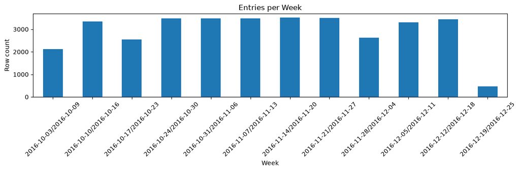

```python
import matplotlib.pyplot as plt

weekly_counts.plot(kind='bar', figsize=(12, 4), title='Entries per Week')
plt.ylabel('Row count')
plt.xlabel('Week')
plt.xticks(rotation=45)
plt.tight_layout()
plt.show()
```

```python
print(model_df['LastUpdated'].max())
```

```
2016-12-19 16:30:00
```

The final week (Dec 19–25) has drastically fewer rows (468 vs. ~3300+ typical). Checking the max timestamp confirms the dataset simply stops on Dec 19 — this isn't a partial day, it's an isolated single day with the rest of that week entirely absent from the data.

```python
cutoff = model_df['LastUpdated'].max() - pd.Timedelta(days=14)
print('Cutoff:', cutoff)
```

```
Cutoff: 2016-12-05 16:30:00
```

```python
pooled_train_df = model_df[model_df['LastUpdated'] < cutoff].copy()
pooled_test_df  = model_df[model_df['LastUpdated'] >= cutoff].copy()

print(f"Train: {pooled_train_df.shape}, {pooled_train_df['LastUpdated'].min()} to {pooled_train_df['LastUpdated'].max()}")
print(f"Test:  {pooled_test_df.shape}, {pooled_test_df['LastUpdated'].min()} to {pooled_test_df['LastUpdated'].max()}")
```

```
Train: (28533, 14), 2016-10-05 08:00:00 to 2016-12-05 16:00:00
Test:  (6778, 14), 2016-12-05 16:30:00 to 2016-12-19 16:30:00
```

```python
train_lots = set(pooled_train_df['SystemCodeNumber'].unique())
test_lots = set(pooled_test_df['SystemCodeNumber'].unique())

print('Lots missing from test:', train_lots - test_lots)
print('Lots missing from train:', test_lots - train_lots)
```

```
Lots missing from test: set()
Lots missing from train: set()
```

```python
feature_cols = ['SystemCodeNumber', 'Capacity', 'hour', 'dayofweek', 'is_weekend',
                 'lag_1step', 'lag_2step', 'lag_1day', 'roll_mean_4']
target_col = 'OccupancyRate'

X_train, y_train = pooled_train_df[feature_cols], pooled_train_df[target_col]
X_test, y_test = pooled_test_df[feature_cols], pooled_test_df[target_col]
```

Feature set excludes `LastUpdated`, `date` (raw datetime — replaced by extracted `hour`/`dayofweek`/`is_weekend`), `Occupancy` (would leak the target directly via `Occupancy/Capacity`), and `was_imputed` (not knowable at genuine forecast time — kept in the dataframe for diagnostics only).

# Baseline Result

Persistence forecast — predict "no change from 30 minutes ago" using `lag_1step` directly. No model, no fitting; this is the floor any real model needs to beat.

```python
#pip install scikit-learn
```

```python
from sklearn.metrics import mean_absolute_error, mean_squared_error
import numpy as np

# Baseline: "predict the last known value" (lag_1step itself)
baseline_pred = X_test['lag_1step']
baseline_mae = mean_absolute_error(y_test, baseline_pred)
baseline_rmse = np.sqrt(mean_squared_error(y_test, baseline_pred))
print(f"Baseline MAE: {baseline_mae:.4f}, RMSE: {baseline_rmse:.4f}")
```

```
Baseline MAE: 0.0479, RMSE: 0.0825
```

# Pooled Model: LightGBM

Train a single model across all lots (with `SystemCodeNumber` as a categorical feature) rather than one model per lot — chosen given the moderate dataset size (~30K rows across 28 lots with ~2.5 months of history), where pooling lets the model borrow strength across lots' shared patterns.

```python
#pip install lightgbm
```

```python
import lightgbm as lgb

train_set = lgb.Dataset(X_train, label=y_train, categorical_feature=['SystemCodeNumber'])
test_set = lgb.Dataset(X_test, label=y_test, categorical_feature=['SystemCodeNumber'], reference=train_set)

params = {
    'objective': 'regression',
    'metric': 'mae',
    'learning_rate': 0.05,
    'num_leaves': 31,          # default; start here, don't overtune yet
    'min_data_in_leaf': 50,    # guards against overfitting on a moderate-size dataset
    'feature_fraction': 0.9,
    'bagging_fraction': 0.8,
    'bagging_freq': 5,
    'verbose': -1,
}

model = lgb.train(
    params,
    train_set,
    num_boost_round=1000,
    valid_sets=[test_set],
    callbacks=[lgb.early_stopping(stopping_rounds=50), lgb.log_evaluation(period=100)]
)

preds = model.predict(X_test, num_iteration=model.best_iteration)
print(f"LightGBM MAE: {mean_absolute_error(y_test, preds):.4f}")
print(f"LightGBM RMSE: {np.sqrt(mean_squared_error(y_test, preds)):.4f}")
```

```
Training until validation scores don't improve for 50 rounds
[100]	valid_0's l1: 0.024332
[200]	valid_0's l1: 0.0225976
[300]	valid_0's l1: 0.0220258
[400]	valid_0's l1: 0.0216382
[500]	valid_0's l1: 0.02148
[600]	valid_0's l1: 0.0213274
[700]	valid_0's l1: 0.0212683
[800]	valid_0's l1: 0.0212081
[900]	valid_0's l1: 0.0211754
Early stopping, best iteration is:
[916]	valid_0's l1: 0.0211716
LightGBM MAE: 0.0212
LightGBM RMSE: 0.0368
```

LightGBM MAE 0.021 vs. baseline 0.048 — roughly 56% error reduction, confirming the lag/rolling/calendar features are capturing real signal beyond simple persistence.

# Pooled Model: XGBoost Training

Trying XGBoost as a second gradient-boosting model for comparison, using the same feature set.

```python
#pip install xgboost
```

```python
import xgboost as xgb

# XGBoost needs explicit categorical encoding or one-hot, unless using enable_categorical
X_train_xgb = X_train.copy()
X_test_xgb = X_test.copy()

model_xgb = xgb.XGBRegressor(
    n_estimators=1000,
    learning_rate=0.05,
    max_depth=6,
    min_child_weight=5,
    subsample=0.8,
    colsample_bytree=0.9,
    enable_categorical=True,
    early_stopping_rounds=50,
    eval_metric='mae'
)

model_xgb.fit(X_train_xgb, y_train, eval_set=[(X_test_xgb, y_test)], verbose=100)
preds_xgb = model_xgb.predict(X_test_xgb)
print(f"XGBoost MAE: {mean_absolute_error(y_test, preds_xgb):.4f}")
```

```
XGBoost MAE: 0.0208
```

```python
xgb_rmse = np.sqrt(mean_squared_error(y_test, preds_xgb))
xgb_mae = mean_absolute_error(y_test, preds_xgb)

print(f"XGBoost MAE: {xgb_mae:.4f}")
print(f"XGBoost RMSE: {xgb_rmse:.4f}")
```

```
XGBoost MAE: 0.0208
XGBoost RMSE: 0.0378
```

# Pooled Model Comparison

Side-by-side comparison of baseline, LightGBM, and XGBoost.

```python
print(f"{'Model':<12} {'MAE':<10} {'RMSE':<10}")
print(f"{'Baseline':<12} {baseline_mae:<10.4f} {baseline_rmse:<10.4f}")
print(f"{'LightGBM':<12} {mean_absolute_error(y_test, preds):<10.4f} {np.sqrt(mean_squared_error(y_test, preds)):<10.4f}")
print(f"{'XGBoost':<12} {xgb_mae:<10.4f} {xgb_rmse:<10.4f}")
```

```
Model        MAE        RMSE
Baseline     0.0479     0.0825
LightGBM     0.0212     0.0368
XGBoost      0.0208     0.0378
```

LightGBM and XGBoost perform nearly identically (MAE ~0.021 each), both well ahead of the naive baseline. The small gap between them (LightGBM has marginally better RMSE) isn't a strong signal either way at this scale — proceeding with LightGBM as the primary model for further tuning and evaluation.

```python
pooled_test_df['pred'] = preds  # or preds_xgb
pooled_test_df['abs_error'] = (pooled_test_df['OccupancyRate'] - pooled_test_df['pred']).abs()
print(pooled_test_df.groupby('was_imputed')['abs_error'].mean())
```

```
was_imputed
False    0.020201
True     0.023978
Name: abs_error, dtype: float64
```

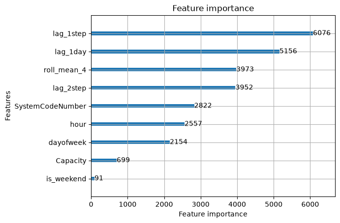

```python
lgb.plot_importance(model, max_num_features=10)
```

```python
pooled_test_df['SystemCodeNumber'] = pooled_test_df['SystemCodeNumber']  # already categorical
per_lot_error = pooled_test_df.groupby('SystemCodeNumber')['abs_error'].mean().sort_values(ascending=False)
print(per_lot_error.head(10))
```

```
SystemCodeNumber
BHMBRCBRG01    0.037325
BHMBRCBRG02    0.030080
BHMBCCTHL01    0.029142
Bull Ring      0.027506
BHMBCCSNH01    0.026662
BHMBCCPST01    0.026583
BHMMBMMBX01    0.025405
BHMEURBRD02    0.023569
BHMEURBRD01    0.023360
BHMNCPNHS01    0.023170
Name: abs_error, dtype: float64
```

# Per-Lot Model: Prophet

Benchmark against a classical per-lot seasonal decomposition approach, using `final_df` directly (no lag features needed — Prophet models temporal structure internally). Same train/test cutoff as the pooled model for a fair comparison.

```python
import pandas as pd

# same cutoff as your pooled model, for fair comparison
cutoff_start = pd.Timestamp('2016-12-05')
cutoff_end = pd.Timestamp('2016-12-19')

final_df_trimmed = final_df[final_df['LastUpdated'] < cutoff_end].copy()

lot_dfs = {
    lot: group[['LastUpdated', 'OccupancyRate']].rename(columns={'LastUpdated': 'ds', 'OccupancyRate': 'y'})
    for lot, group in final_df_trimmed.groupby('SystemCodeNumber', observed=True)
}

print(f"Number of lots: {len(lot_dfs)}")
print(lot_dfs[list(lot_dfs.keys())[0]].head())
```

```
Number of lots: 28
                   ds         y
1 2016-10-04 08:00:00  0.110919
2 2016-10-04 08:30:00  0.138648
3 2016-10-04 09:00:00  0.180676
4 2016-10-04 09:30:00  0.222704
5 2016-10-04 10:00:00  0.306759
```

```python
#pip install prophet
```

```python
from prophet import Prophet
from sklearn.metrics import mean_absolute_error, mean_squared_error
import numpy as np

results = {}

for lot, df_lot in lot_dfs.items():
    train = df_lot[df_lot['ds'] < cutoff_start]
    test = df_lot[df_lot['ds'] >= cutoff_start]

    if len(train) < 50 or len(test) < 10:   # skip lots with too little data either side
        continue

    m = Prophet(
        daily_seasonality=True,
        weekly_seasonality=True,
        yearly_seasonality=False,   # only ~2.5 months of data, not enough for yearly patterns
        changepoint_prior_scale=0.05  # default; controls trend flexibility — lower = more conservative
    )
    m.fit(train)

    forecast = m.predict(test[['ds']])
    preds = forecast['yhat'].clip(0, 1).values  # clip to valid occupancy rate range

    mae = mean_absolute_error(test['y'], preds)
    rmse = np.sqrt(mean_squared_error(test['y'], preds))
    results[lot] = {'mae': mae, 'rmse': rmse, 'n_test': len(test)}

results_df = pd.DataFrame(results).T.sort_values('mae')
print(results_df)
print(results_df[['mae', 'rmse']].mean())
```

```
                       mae      rmse  n_test
NIA Car Parks     0.040941  0.051091   166.0
BHMBRCBRG03       0.045490  0.061031   252.0
Others-CCCPS202   0.047358  0.053776   252.0
BHMNCPPLS01       0.057475  0.079855   252.0
BHMNCPNHS01       0.057793  0.085133   219.0
Others-CCCPS98    0.058759  0.079961   252.0
NIA South         0.059281  0.075095   166.0
BHMNCPRAN01       0.060069  0.078004   222.0
Others-CCCPS119a  0.063450  0.086711   252.0
BHMEURBRD01       0.066854  0.090863   252.0
BHMNCPLDH01       0.066895  0.085366   234.0
Others-CCCPS135a  0.072491  0.086140   252.0
BHMBCCTHL01       0.073052  0.112503   252.0
Others-CCCPS133   0.074778  0.097149   252.0
BHMBCCMKT01       0.074870  0.097016   252.0
Others-CCCPS8     0.075542  0.089738   252.0
BHMNCPHST01       0.080267  0.095111   252.0
Shopping          0.080588  0.096021   252.0
Bull Ring         0.081267  0.109472   252.0
BHMNCPNST01       0.082291  0.097892   252.0
Others-CCCPS105a  0.082605  0.098639   252.0
Broad Street      0.083775  0.102847   252.0
BHMBCCSNH01       0.091208  0.119135   234.0
BHMBCCPST01       0.093512  0.127794   219.0
BHMBRCBRG01       0.094364  0.136995   252.0
BHMMBMMBX01       0.110151  0.140733   252.0
BHMBRCBRG02       0.111881  0.147692   252.0
BHMEURBRD02       0.139242  0.166536   252.0
mae     0.075938
rmse    0.098154
dtype: float64
```

Prophet performs substantially worse than pooled LightGBM (MAE 0.076 vs. 0.021) — roughly 3–4x worse, and even worse than the naive baseline for several lots. With only ~2 months of history per lot, there isn't enough data for Prophet's seasonal decomposition to reliably separate trend/weekly/daily components in isolation. The pooled ML approach, which borrows strength across all 28 lots simultaneously and leans on recent-lag information (a stronger short-horizon signal than "typical Tuesday" seasonality), is the clear winner. Given this gap, SARIMA — a more rigid classical alternative — isn't worth pursuing further.

# LightGBM Hyperparameter Tuning

A small, deliberate sweep (not a full grid search) around the current LightGBM config, to check whether there's meaningful headroom before finalizing the model.

```python
train_set = lgb.Dataset(
    X_train, label=y_train,
    categorical_feature=['SystemCodeNumber'],
    params={'feature_pre_filter': False}
)
test_set = lgb.Dataset(
    X_test, label=y_test,
    categorical_feature=['SystemCodeNumber'],
    reference=train_set
)

configs = {
    'baseline (current)': {
        'learning_rate': 0.05, 'num_leaves': 31, 'min_data_in_leaf': 50,
        'feature_fraction': 0.9, 'bagging_fraction': 0.8, 'bagging_freq': 5,
    },
    'smaller_leaves': {
        'learning_rate': 0.05, 'num_leaves': 15, 'min_data_in_leaf': 50,
        'feature_fraction': 0.9, 'bagging_fraction': 0.8, 'bagging_freq': 5,
    },
    'more_leaves': {
        'learning_rate': 0.05, 'num_leaves': 63, 'min_data_in_leaf': 30,
        'feature_fraction': 0.9, 'bagging_fraction': 0.8, 'bagging_freq': 5,
    },
    'slower_lr': {
        'learning_rate': 0.02, 'num_leaves': 31, 'min_data_in_leaf': 50,
        'feature_fraction': 0.9, 'bagging_fraction': 0.8, 'bagging_freq': 5,
    },
    'less_regularized': {
        'learning_rate': 0.05, 'num_leaves': 31, 'min_data_in_leaf': 20,
        'feature_fraction': 1.0, 'bagging_fraction': 1.0, 'bagging_freq': 0,
    },
}

tuning_results = {}

for name, cfg in configs.items():
    params = {'objective': 'regression', 'metric': 'mae', 'verbose': -1, **cfg}
    m = lgb.train(
        params, train_set, num_boost_round=2000,
        valid_sets=[test_set],
        callbacks=[lgb.early_stopping(stopping_rounds=50, verbose=False)]
    )
    preds = m.predict(X_test, num_iteration=m.best_iteration)
    mae = mean_absolute_error(y_test, preds)
    rmse = np.sqrt(mean_squared_error(y_test, preds))
    tuning_results[name] = {'mae': mae, 'rmse': rmse, 'best_iter': m.best_iteration}

print(pd.DataFrame(tuning_results).T.sort_values('mae'))
```

```
                         mae      rmse  best_iter
slower_lr           0.020892  0.036112     2000.0
less_regularized    0.020981  0.037089     1003.0
more_leaves         0.021057  0.036709      693.0
baseline (current)  0.021172  0.036776      916.0
smaller_leaves      0.021273  0.036376     1495.0
```

# Final Evaluation

Diagnostic checks on the finalized LightGBM model: per-lot error, temporal error patterns, sensitivity to imputed data, residual bias, and error distribution. See the evaluation write-up cell at the end of this notebook for the full narrative summary.

```python
pooled_test_df['pred'] = preds  # from your best LightGBM model
pooled_test_df['abs_error'] = (pooled_test_df['OccupancyRate'] - pooled_test_df['pred']).abs()

per_lot_error = pooled_test_df.groupby('SystemCodeNumber', observed=True)['abs_error'].mean().sort_values(ascending=False)
print(per_lot_error)
```

```
SystemCodeNumber
BHMBRCBRG01         0.038177
BHMBCCTHL01         0.029879
BHMBRCBRG02         0.029016
BHMBCCSNH01         0.027133
Bull Ring           0.027031
BHMBCCPST01         0.026608
BHMMBMMBX01         0.025884
BHMEURBRD02         0.024210
BHMEURBRD01         0.022866
BHMNCPNHS01         0.021948
Others-CCCPS133     0.021746
BHMBCCMKT01         0.021605
BHMNCPRAN01         0.020674
Broad Street        0.019716
BHMNCPNST01         0.018682
BHMBRCBRG03         0.018653
Others-CCCPS105a    0.018524
Others-CCCPS135a    0.017917
BHMNCPLDH01         0.017917
BHMNCPPLS01         0.017551
BHMNCPHST01         0.017269
Others-CCCPS8       0.016955
Shopping            0.016159
Others-CCCPS98      0.016074
Others-CCCPS119a    0.014253
NIA South           0.014056
Others-CCCPS202     0.010984
NIA Car Parks       0.009068
Name: abs_error, dtype: float64
```

```python
pooled_test_df.groupby('hour')['abs_error'].mean()
```

```
hour
8     0.050624
9     0.017836
10    0.016407
11    0.014864
12    0.012850
13    0.011295
14    0.013368
15    0.012185
16    0.038393
Name: abs_error, dtype: float64
```

```python
pooled_test_df.groupby('dayofweek')['abs_error'].mean()
```

```
dayofweek
0    0.022157
1    0.018556
2    0.015415
3    0.019592
4    0.022461
5    0.026685
6    0.022731
Name: abs_error, dtype: float64
```

```python
pooled_test_df.groupby('was_imputed')['abs_error'].mean()
```

```
was_imputed
False    0.019943
True     0.023984
Name: abs_error, dtype: float64
```

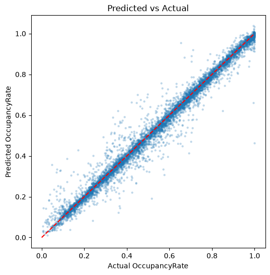

```python
import matplotlib.pyplot as plt

plt.figure(figsize=(6,6))
plt.scatter(pooled_test_df['OccupancyRate'], pooled_test_df['pred'], alpha=0.2, s=5)
plt.plot([0,1],[0,1],'r--')  # perfect prediction line
plt.xlabel('Actual OccupancyRate')
plt.ylabel('Predicted OccupancyRate')
plt.title('Predicted vs Actual')
plt.savefig('C:\\Users\\aacha\\OneDrive\\Desktop\\birmingham_plots\\residual_plot', dpi=300, bbox_inches='tight')
plt.show()
```

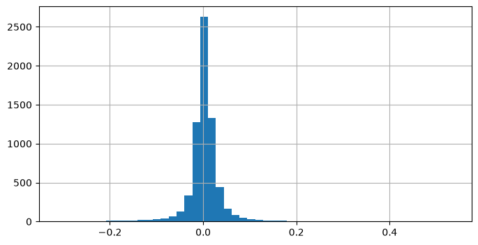

```python
pooled_test_df['error'] = pooled_test_df['OccupancyRate'] - pooled_test_df['pred']
pooled_test_df['error'].hist(bins=50, figsize=(8,4))
plt.savefig(
    "C:\\Users\\aacha\\OneDrive\\Desktop\\birmingham_plots\\error_distribution_hist",
    dpi=300,
    bbox_inches="tight",
)
plt.show()
```

```python
print(pooled_test_df['error'].describe())
```

```
count    6778.000000
mean        0.002641
std         0.036997
min        -0.310148
25%        -0.008675
50%         0.002375
75%         0.014847
max         0.533497
Name: error, dtype: float64
```

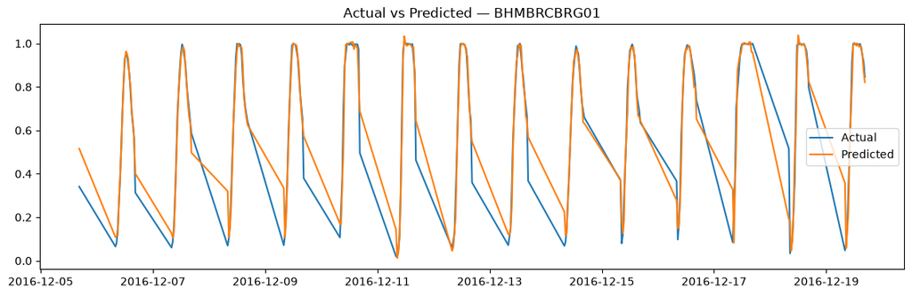

```python
sample_lot = pooled_test_df[pooled_test_df['SystemCodeNumber'] == per_lot_error.index[0]]  # worst-performing lot
plt.figure(figsize=(14,4))
plt.plot(sample_lot['LastUpdated'], sample_lot['OccupancyRate'], label='Actual')
plt.plot(sample_lot['LastUpdated'], sample_lot['pred'], label='Predicted')
plt.legend()
plt.title(f"Actual vs Predicted — {per_lot_error.index[0]}")
plt.savefig('C:\\Users\\aacha\\OneDrive\\Desktop\\birmingham_plots\\visual_timeseries', dpi=300, bbox_inches='tight')
plt.show()
```

**Per-lot error.** Mean absolute error ranged from 0.009 (NIA Car Parks) to 0.038 (BHMBRCBRG01) across the 28 lots — roughly a 4x spread. The worst-performing lots (BHMBRCBRG01, BHMBCCTHL01, BHMBRCBRG02) are the same lots flagged earlier in preprocessing for capacity-overshoot issues, suggesting their underlying occupancy dynamics are genuinely noisier or less consistent, not just harder for the model to learn. The best-performing lots (NIA Car Parks, Others-CCCPS202, NIA South) had errors below 0.015, indicating the model performs very well for the majority of lots even though a handful drag up the overall average.

**Error by hour.** Error is lowest during the stable midday period (11:00–15:00, MAE ~0.011–0.015) and highest at the operating-hours boundaries — 8:00 (0.051) and 16:00 (0.038). This is expected: these are the transition points where occupancy is rising or falling most steeply, so a lag-based model has the least reliable recent signal to extrapolate from. Predictions should be treated with more caution near opening and closing.

**Error by day of week.** Weekday error (Mon–Fri: 0.015–0.022) is generally lower than weekend error (Sat: 0.027, Sun: 0.023), though the spread is modest. This suggests weekday demand patterns are somewhat more regular/predictable than weekend patterns, consistent with the higher raw missingness observed in weekend data during preprocessing.

**Imputed vs. observed rows.** Rows that were originally missing and filled via interpolation show slightly higher error (MAE 0.024) than genuinely observed rows (MAE 0.020). The gap is small, indicating the model isn't being propped up by "easy" interpolated values, but it's a reasonable caveat: a small share of test performance is measured against synthetic rather than real data.

**Residual bias (predicted vs. actual).** The scatter plot shows predictions tracking the actual occupancy rate closely across the full 0–1 range, with points clustering tightly along the diagonal. A small number of outliers appear at low actual occupancy with high predicted occupancy (and vice versa), but there is no systematic directional bias — the model does not consistently over- or under-predict at any particular occupancy level.

**Error distribution.** Residuals (actual − predicted) are centered near zero (mean 0.0026, median 0.0024) with a standard deviation of 0.037, confirming the model is essentially unbiased on average. The distribution is sharply peaked but has a longer right tail (max residual 0.53) than left (min −0.31), meaning under-prediction of occupancy (real occupancy higher than forecast) is the rarer but more severe failure mode when it occurs — worth noting for any downstream use where under-forecasting capacity is more costly than over-forecasting it.

**Time series inspection.** A close look at the worst-performing lot (BHMBRCBRG01) shows the model tracks the daily rise-fall occupancy cycle well overall, correctly capturing the shape and timing of peaks. The main recurring miss is a slight lag/smoothing effect on the descending (evening) leg of each cycle — the model tends to predict a slower decline than actually occurs, consistent with the hour-16 error spike noted above.

**Summary.** The model shows strong, largely unbiased performance (MAE 0.021 pooled, well below the 0.048 naive baseline), with identifiable and explainable weak points: a few structurally noisier lots, the two operating-hour boundary periods, and a mild tendency to lag behind rapid evening declines. These are reasonable limitations for a lag-feature-based short-horizon forecaster and do not indicate a fundamental flaw in the modeling approach.

```python
print("Raw parking negative Occupancy:", (parking['Occupancy'] < 0).sum())
```

```
Raw parking negative Occupancy: 12
```

```python
# 2. Check final_df (post-cleaning base table)
print("final_df negative Occupancy:", (final_df['Occupancy'] < 0).sum())
print("final_df negative OccupancyRate:", (final_df['OccupancyRate'] < 0).sum())
```

```
final_df negative Occupancy: 0
final_df negative OccupancyRate: 0
```

```python
# 3. Check model_df (feature-engineered table, includes lags)
print("model_df negative OccupancyRate:", (model_df['OccupancyRate'] < 0).sum())
print("model_df negative lag_1step:", (model_df['lag_1step'] < 0).sum())
print("model_df negative lag_2step:", (model_df['lag_2step'] < 0).sum())
print("model_df negative lag_1day:", (model_df['lag_1day'] < 0).sum())
print("model_df negative roll_mean_4:", (model_df['roll_mean_4'] < 0).sum())
```

```
model_df negative OccupancyRate: 0
model_df negative lag_1step: 0
model_df negative lag_2step: 0
model_df negative lag_1day: 0
model_df negative roll_mean_4: 0
```

```python
# 4. Check the actual train/test splits used for modeling
print("y_train negative:", (y_train < 0).sum())
print("y_test negative:", (y_test < 0).sum())
print("X_train lag columns negative:")
print((X_train[['lag_1step', 'lag_2step', 'lag_1day', 'roll_mean_4']] < 0).sum())
```

```
y_train negative: 0
y_test negative: 0
X_train lag columns negative:
lag_1step      0
lag_2step      0
lag_1day       0
roll_mean_4    0
dtype: int64
```

# Summary & Limitations

- **Best model:** pooled LightGBM, MAE 0.021 (vs. 0.048 naive baseline)
- **Excluded:** 2 lots with poor data coverage (`NIA North`, `BHMBRTARC01`); rows with gaps longer than 2 hours (7.5% of resampled data)
- **Known weak points:** a handful of structurally noisier lots (capacity-overshoot lots), the two operating-hour boundaries (8am/4pm), and a mild lag effect on rapid evening occupancy declines
- **Scope:** short-horizon (30-min-ahead) forecasting during business hours (8am–4pm) only; not validated for multi-step or overnight forecasting